# Differentiation potency of fetal and adult MSCs by single-cell entropy (SCENT)

Signalling entropy rate across osteogenic differentiation, each cohort normalised separately

Charles

24 August 2026

# 1 Background

This document computes the **signalling entropy rate (SR)** for the fetal (fMSC) and adult (aMSC) osteogenic differentiation time courses, following

> Teschendorff AE, Enver T. *Single-cell entropy for accurate estimation of differentiation potency from a cell’s transcriptome.* **Nat Commun** 8:15599 (2017). doi:10.1038/ncomms15599

with the method as originally introduced in Banerji *et al.*, *Sci Rep* 3:3039 (2013).

SR treats the transcriptome as a weighting of a protein-protein interaction (PPI) network and measures the *promiscuity* of signalling flux over that network. A random walk is defined on the PPI adjacency matrix $A$ with the expression vector $x$ as node weights,

$$p_{ij} = \frac{a_{ij}\,x_j}{s_i}, \qquad
s_i = \sum_j a_{ij} x_j,$$

whose stationary distribution is $\pi_i = x_i s_i / \sum_k x_k s_k$. With local entropies $S_i = -\sum_j p_{ij}\log p_{ij}$, the global rate is normalised by the maximum entropy rate of the network, $\log\lambda_{\max}(A)$:

$$\mathrm{SR} = \frac{\sum_i \pi_i
S_i}{\log \lambda_{\max}(A)} \in [0,1].$$

High SR means signalling flux is spread broadly over the network — the signature of an undifferentiated, high-potency state. SR falls as cells commit.

**Scope note.** These are bulk RNA-seq libraries, not single cells. SR is well defined on bulk data (that is where the method originated), but a bulk value is a population average and cannot resolve potency heterogeneity *between* cells, which is the specific contribution of the 2017 paper. Interpret each value as the mean potency of the population in that well.

# 2 Cohorts are scored separately

The fetal and adult cohorts were sequenced in different batches, so cohort is confounded with batch. Both cohorts are therefore processed **independently and in sequence** in this one document: gene filtering, the variance-stabilising transform, and the PPI subnetwork are all derived within a cohort, and no cross-cohort normalisation is attempted.

The consequence is that **the two sets of SR values are not on a common scale**. Each cohort yields a different set of expressed genes, hence a different maximally connected subnetwork and a different normalising constant $\log\lambda_{\max}$. Within-cohort contrasts — time, and OD versus CTRL — are unaffected and are the intended readout. The combined figure below uses free y-axes for that reason, and no fetal-versus-adult test is performed.

# 3 Dependencies

```r
# Run once. SCENT is not on CRAN/Bioconductor.
#install.packages(c("igraph", "Matrix", "ggplot2", "dplyr", "tidyr", "knitr"))
#if (!requireNamespace("BiocManager", quietly = TRUE)) install.packages("BiocManager")
#BiocManager::install(c("DESeq2", "org.Hs.eg.db", "AnnotationDbi"))
#remotes::install_github("aet21/SCENT")   # optional; a fallback is provided below
```

```r
library(Matrix)
library(igraph)
library(DESeq2)
library(org.Hs.eg.db)
library(AnnotationDbi)
library(dplyr)
library(tidyr)
library(ggplot2)

PROJECT <- normalizePath("/Users/yuk.kit.lor/Library/CloudStorage/OneDrive-KarolinskaInstitutet/Longitudinal Osteogenic Differentiation/Submission/fetal_adult_RNA_seq/")        # repository root, from reports/scent/
OUTDIR  <- file.path(PROJECT, "output", "scent")
dir.create(OUTDIR, showWarnings = FALSE, recursive = TRUE)

COHORTS <- c("fetal", "adult")
TORDER  <- c("D0", "D1", "D2", "D3", "D4", "D10", "D17")
PAL     <- c(Base = "grey40", OD = "#c0392b", CTRL = "#2980b9")
```

# 4 Input data

```r
counts_all <- read.csv(file.path(PROJECT, "data", "rawcounts.csv"),
                       row.names = 1, check.names = FALSE)
rownames(counts_all) <- sub("\\..*$", "", rownames(counts_all))  # strip versions

coldata <- read.csv(file.path(PROJECT, "data", "coldata_merged.csv"),
                    row.names = 1, check.names = FALSE)
coldata$SR <- NULL                       # recomputing from scratch here

cat(sprintf("counts: %d genes x %d libraries\n",
            nrow(counts_all), ncol(counts_all)))
```

```
## counts: 60664 genes x 91 libraries
```

```r
table(coldata$cohort, coldata$Condition)
```

```
##
##         Base CTRL OD
##   adult    3   18 18
##   fetal    4   24 24
```

The `net17Jan16` network shipped with SCENT (11,751 nodes, Entrez IDs, derived from Pathway Commons). A copy lives in the repository so this document is self-contained. **SR values are only comparable within a fixed network and normalisation** — the smaller `net13Jun12` network from the 2017 paper puts the same samples near 0.916 rather than 0.966.

```r
load(file.path(PROJECT, "data", "ppi", "net17Jan16.rda"))   # -> net17Jan16.m
net <- net17Jan16.m
cat(sprintf("PPI network: %d nodes, %d edges\n", nrow(net), sum(net) / 2))
```

```
## PPI network: 11751 nodes, 1504486 edges
```

# 5 Method implementation

`DoIntegPPI` intersects the expression matrix with the network and keeps the maximally connected component; `CompSRana` computes SR per sample. If the SCENT package is not installed, the fallback below implements the identical formulas. It uses the closed form (exact for a binary adjacency matrix)

$$S_i = \log s_i - \frac{\bigl(A\,(x \odot
\log x)\bigr)_i}{s_i}$$

which avoids ever allocating the dense $n \times n$ stochastic matrix.

```r
integ_ppi <- function(exp.m, ppiA.m) {
  common <- intersect(rownames(ppiA.m), rownames(exp.m))
  stopifnot(length(common) >= 5000)
  adj <- ppiA.m[common, common]
  cl  <- igraph::components(igraph::graph_from_adjacency_matrix(
           adj, mode = "undirected"))
  mc  <- which(cl$membership == which.max(cl$csize))
  adj <- adj[mc, mc]
  list(expMC = exp.m[rownames(adj), ], adjMC = adj)
}

comp_max_sr <- function(adj.m) {
  fa <- function(x, extra = NULL) as.vector(adj.m %*% x)
  ap <- igraph::arpack(fa, options = list(n = nrow(adj.m), nev = 1, which = "LM"),
                       sym = TRUE)
  log(ap$values)
}

comp_sr <- function(integ.l) {
  A <- Matrix::Matrix(integ.l$adjMC, sparse = TRUE)
  maxSR <- comp_max_sr(integ.l$adjMC)
  sr <- apply(integ.l$expMC, 2, function(x) {
    s  <- as.vector(A %*% x)
    S  <- log(s) - as.vector(A %*% (x * log(x))) / s   # local entropies
    pi <- x * s; pi <- pi / sum(pi)                    # stationary distribution
    sum(pi * S) / maxSR
  })
  list(SR = sr, maxSR = maxSR)
}
```

`score_cohort()` runs the whole per-cohort pipeline: subset, gene filter (>= 10 counts in >= half that cohort’s libraries), blind `DESeq2::vst`, Ensembl to Entrez mapping (most highly expressed gene wins where several map to one Entrez ID), network integration, and SR.

```r
score_cohort <- function(cohort) {
  message("=== ", cohort, " ===")
  smp <- coldata[coldata$cohort == cohort, ]
  smp <- smp[order(smp$Donor, as.integer(sub("D", "", smp$Time)), smp$Condition), ]
  cts <- counts_all[, rownames(smp)]
  smp$Donor <- factor(make.names(smp$Donor))     # DESeq2 dislikes spaces

  keep <- rowSums(cts >= 10) >= floor(0.5 * ncol(cts))
  message(sprintf("  %d libraries, %d donors, kept %d / %d genes",
                  ncol(cts), dplyr::n_distinct(smp$Donor), sum(keep), length(keep)))

  dds  <- DESeqDataSetFromMatrix(round(as.matrix(cts[keep, ])),
                                 colData = smp, design = ~ Donor)
  expr <- assay(vst(dds, blind = TRUE))
  stopifnot(min(expr) > 0)                       # SR needs strictly positive input

  ez   <- AnnotationDbi::mapIds(org.Hs.eg.db, keys = rownames(expr),
                                keytype = "ENSEMBL", column = "ENTREZID",
                                multiVals = "first")
  expr <- expr[!is.na(ez), ]; ez <- ez[!is.na(ez)]
  ord  <- order(rowMeans(expr), decreasing = TRUE)
  expr <- expr[ord, ]; ez <- ez[ord]
  dup  <- duplicated(ez)
  expr <- expr[!dup, ]; rownames(expr) <- ez[!dup]

  if (requireNamespace("SCENT", quietly = TRUE)) {
    integ <- SCENT::DoIntegPPI(exp.m = expr, ppiA.m = net)
    sr    <- SCENT::CompSRana(integ, local = FALSE, mc.cores = 1)$SR
    names(sr) <- colnames(integ$expMC)   # CompSRana returns an unnamed vector
    maxsr <- comp_max_sr(integ$adjMC)
  } else {
    integ <- integ_ppi(expr, net)
    res   <- comp_sr(integ)
    sr    <- res$SR; maxsr <- res$maxSR
  }

  smp$SR   <- as.numeric(sr[rownames(smp)])
  smp$day  <- as.integer(sub("D", "", smp$Time))
  smp$Time <- factor(smp$Time, levels = TORDER)
  message(sprintf("  subnetwork %d genes, maxSR = %.4f, SR %.5f - %.5f",
                  nrow(integ$adjMC), maxsr, min(smp$SR), max(smp$SR)))

  list(cohort = cohort, smp = smp, n_genes = nrow(integ$adjMC),
       n_edges = sum(integ$adjMC) / 2, maxSR = maxsr, n_kept = sum(keep))
}
```

Reporting helpers, so each cohort section is a single call.

```r
# Reference values from the equivalent Python implementation on the same inputs.
EXPECTED <- list(
  fetal = list(genes = 8361, maxSR = 6.9282, mean = 0.96622, lo = 0.96518, hi = 0.96747),
  adult = list(genes = 8511, maxSR = 6.9309, mean = 0.96571, lo = 0.96480, hi = 0.96664)
)

check_tbl <- function(res) {
  e <- EXPECTED[[res$cohort]]
  knitr::kable(data.frame(
    quantity = c("genes in connected component", "maxSR", "mean SR", "min SR", "max SR"),
    expected = c(e$genes, e$maxSR, e$mean, e$lo, e$hi),
    observed = c(res$n_genes, res$maxSR, mean(res$smp$SR),
                 min(res$smp$SR), max(res$smp$SR))
  ), digits = 5,
  caption = sprintf("%s cohort: observed versus reference values", res$cohort))
}

plot_traj <- function(res) {
  ggplot(res$smp, aes(Time, SR, colour = Condition, group = Condition)) +
    stat_summary(fun = mean, geom = "line", linewidth = 1.1) +
    stat_summary(fun.data = mean_se, geom = "pointrange", size = 0.6) +
    scale_colour_manual(values = PAL) +
    labs(x = "day", y = "signalling entropy rate (SR)", colour = NULL,
         title = sprintf("%s MSC potency across osteogenic differentiation",
                         res$cohort),
         subtitle = sprintf("%d libraries, %d donors, %d network genes",
                            nrow(res$smp), dplyr::n_distinct(res$smp$Donor),
                            res$n_genes)) +
    theme_classic(base_size = 13)
}

plot_donors <- function(res) {
  ggplot(res$smp, aes(day, SR, colour = Condition)) +
    geom_point(size = 1.8) + geom_line(aes(group = Condition), alpha = 0.7) +
    facet_wrap(~ Donor, nrow = 1) +
    scale_colour_manual(values = PAL) +
    labs(x = "day", y = "SR", colour = NULL) +
    theme_bw(base_size = 12)
}

stats_for <- function(res) {
  smp <- res$smp
  trend <- lapply(c("OD", "CTRL"), function(arm) {
    s  <- smp[smp$Condition %in% c(arm, "Base"), ]
    ct <- cor.test(s$day, s$SR, method = "spearman", exact = FALSE)
    data.frame(cohort = res$cohort, test = paste("SR vs day,", arm, "arm"),
               n = nrow(s), statistic = unname(ct$estimate), p = ct$p.value)
  }) %>% bind_rows()

  w <- smp %>%
    filter(Condition %in% c("OD", "CTRL")) %>%
    select(Donor, Time, Condition, SR) %>%
    pivot_wider(names_from = Condition, values_from = SR) %>%
    tidyr::drop_na()
  wt <- wilcox.test(w$OD, w$CTRL, paired = TRUE)

  bind_rows(trend,
    data.frame(cohort = res$cohort, test = "OD vs CTRL (paired, donor x day)",
               n = nrow(w), statistic = unname(wt$statistic), p = wt$p.value))
}
```

# 6 Run both cohorts

Fetal first, then adult. Each pass is fully independent of the other.

```r
fits <- lapply(COHORTS, score_cohort)
names(fits) <- COHORTS
```

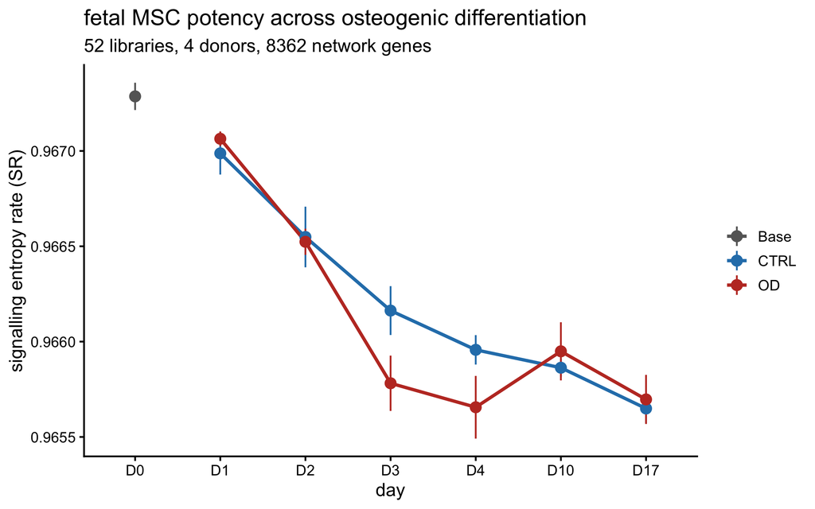

```r
plot_traj(fits$fetal)
```

```r
ggsave(file.path(OUTDIR, "fig_fetal_sr_trajectory_R.png"), width = 8, height = 5, dpi = 200)
ggsave(file.path(OUTDIR, "fig_fetal_sr_trajectory_R.pdf"), width = 8, height = 5)
```

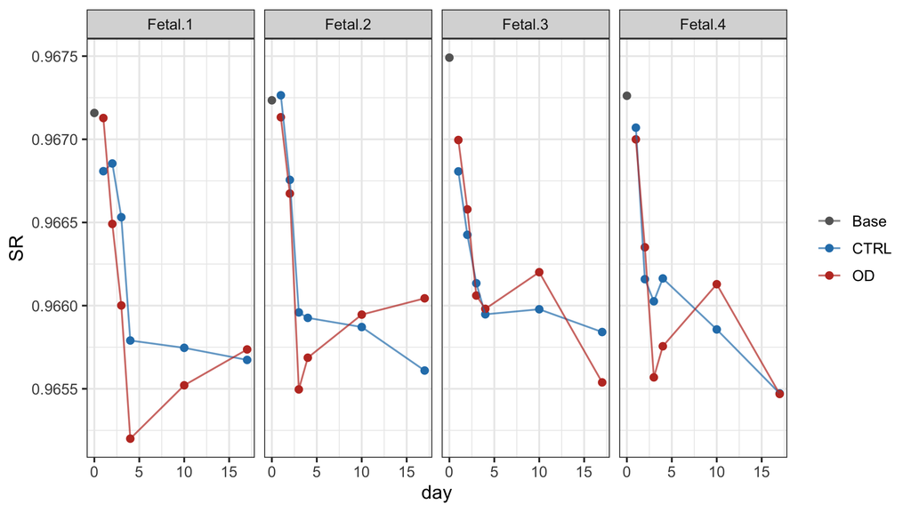

```r
plot_donors(fits$fetal)
```

# 7 Adult cohort

```r
check_tbl(fits$adult)
```

adult cohort: observed versus reference values

| quantity | expected | observed |
| --- | --- | --- |
| genes in connected component | 8511.00000 | 8512.00000 |
| maxSR | 6.93090 | 6.93039 |
| mean SR | 0.96571 | 0.96572 |
| min SR | 0.96480 | 0.96481 |
| max SR | 0.96664 | 0.96666 |

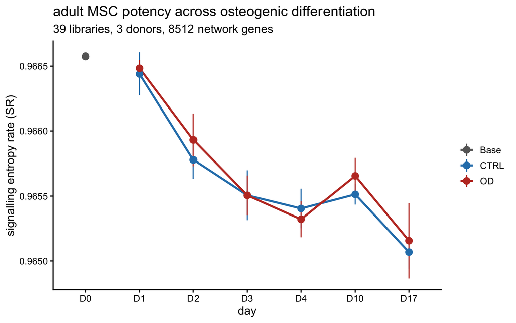

```r
plot_traj(fits$adult)
```

```r
ggsave(file.path(OUTDIR, "fig_adult_sr_trajectory_R.png"), width = 8, height = 5, dpi = 200)
ggsave(file.path(OUTDIR, "fig_adult_sr_trajectory_R.pdf"), width = 8, height = 5)
```

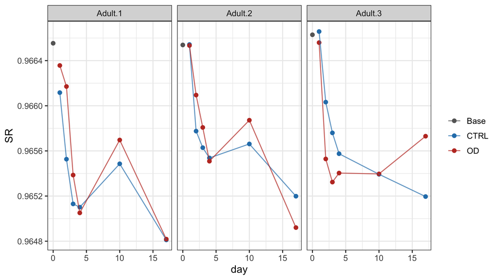

```r
plot_donors(fits$adult)
```

# 8 Combined output

Per-sample SR for both cohorts in one table. The `cohort` column is not a factor you may test across — see the caveat above.

```r
sr_all <- bind_rows(lapply(fits, function(r)
  r$smp[, c("cohort", "Donor", "Condition", "Time", "Stage", "day", "SR")]))
write.csv(sr_all, file.path(OUTDIR, "scent_sr_both_cohorts_R.csv"))

net_tbl <- bind_rows(lapply(fits, function(r) data.frame(
  cohort = r$cohort, genes_kept = r$n_kept, network_genes = r$n_genes,
  network_edges = r$n_edges, maxSR = r$maxSR,
  mean_SR = mean(r$smp$SR), sd_SR = sd(r$smp$SR))))
knitr::kable(net_tbl, digits = 5,
             caption = "Per-cohort normalisation and network summary")
```

Per-cohort normalisation and network summary

| cohort | genes_kept | network_genes | network_edges | maxSR | mean_SR | sd_SR |
| --- | --- | --- | --- | --- | --- | --- |
| fetal | 14488 | 8362 | 1279767 | 6.92769 | 0.96624 | 0.00060 |
| adult | 15329 | 8512 | 1291977 | 6.93039 | 0.96572 | 0.00054 |

Free y-axes: the panels show the shape of each trajectory, not a difference in level between cohorts.

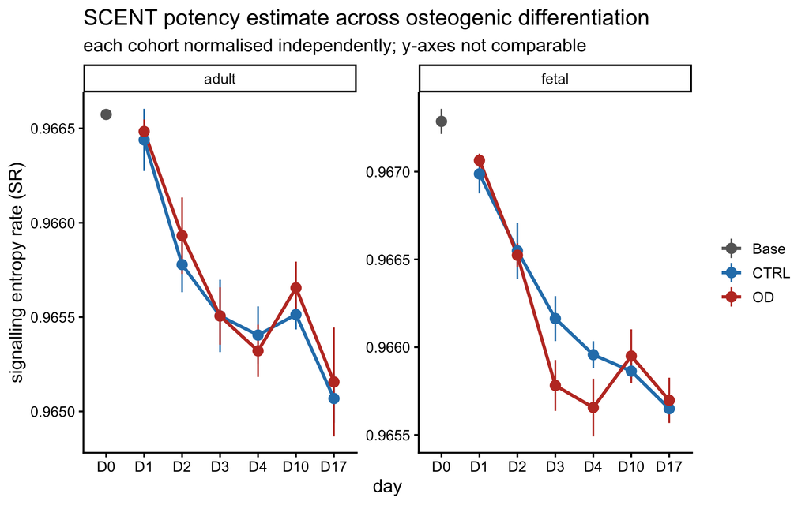

```r
ggplot(sr_all, aes(Time, SR, colour = Condition, group = Condition)) +
  stat_summary(fun = mean, geom = "line", linewidth = 1.1) +
  stat_summary(fun.data = mean_se, geom = "pointrange", size = 0.55) +
  facet_wrap(~ cohort, scales = "free_y") +
  scale_colour_manual(values = PAL) +
  labs(x = "day", y = "signalling entropy rate (SR)", colour = NULL,
       title = "SCENT potency estimate across osteogenic differentiation",
       subtitle = "each cohort normalised independently; y-axes not comparable") +
  theme_classic(base_size = 13)
```

```r
ggsave(file.path(OUTDIR, "fig_sr_trajectory_both_R.png"), width = 10, height = 5, dpi = 200)
ggsave(file.path(OUTDIR, "fig_sr_trajectory_both_R.pdf"), width = 10, height = 5)
```

## 8.1 Statistics

Within-cohort tests only: SR versus time in each arm (the D0 baseline is shared and enters both), and osteogenic induction versus control paired within donor and day.

```r
stats_tbl <- bind_rows(lapply(fits, stats_for))
knitr::kable(stats_tbl, digits = c(0, 0, 0, 3, 8),
             caption = "Signalling entropy rate, within-cohort statistics")
```

Signalling entropy rate, within-cohort statistics

| cohort | test | n | statistic | p |
| --- | --- | --- | --- | --- |
| fetal | SR vs day, OD arm | 28 | -0.818 | 0.00000011 |
| fetal | SR vs day, CTRL arm | 28 | -0.942 | 0.00000000 |
| fetal | OD vs CTRL (paired, donor x day) | 24 | 105.000 | 0.20761657 |
| adult | SR vs day, OD arm | 21 | -0.786 | 0.00002367 |
| adult | SR vs day, CTRL arm | 21 | -0.841 | 0.00000175 |
| adult | OD vs CTRL (paired, donor x day) | 18 | 102.000 | 0.49507904 |

```r
write.csv(stats_tbl, file.path(OUTDIR, "scent_sr_stats_both_R.csv"), row.names = FALSE)

get_stat <- function(coh, pattern, what = "statistic")
  stats_tbl[stats_tbl$cohort == coh & grepl(pattern, stats_tbl$test), what][1]
```

Reference values from the Python run: fetal OD $\rho = -0.82$ ($p = 1.1\times10^{-7}$), fetal CTRL $\rho = -0.94$ ($p = 8.1\times10^{-14}$), OD versus CTRL $p = 0.19$; adult OD $\rho = -0.79$ ($p = 2.4\times10^{-5}$), adult CTRL $\rho = -0.84$ ($p = 1.8\times10^{-6}$), OD versus CTRL $p = 0.47$.

# 9 Interpretation

The decline is, however, at least as steep in the non-induced control arm (fetal $\rho$ = -0.94, adult $\rho$ = -0.84), and osteogenic induction adds no detectable further drop once donor and day are matched (fetal $p$ = 0.21, adult $p$ = 0.50). On this dataset SR therefore tracks **time in culture — confluence, contact inhibition, replicative age — rather than osteogenic commitment specifically**. It should not be presented as a readout of the differentiation being induced without an experiment that separates culture duration from induction, for instance density-matched sampling or a second differentiation lineage as a comparator.

Because the cohorts are confounded with sequencing batch and are normalised separately here, the fetal and adult SR values describe within-cohort dynamics only and are not contrasted with each other.